[GitHub](https://github.com/agate-model/workshops)[](https://github.com/agate-model/workshops/blob/main/2026-05/examples/04_number_and_size.jl)

# Exercise 04: Number and size

Info

This exercise uses [Oceananigans.jl](https://clima.github.io/OceananigansDocumentation/stable/) and [OceanBioME.jl](https://oceanbiome.github.io/OceanBioME.jl/stable/). We recommend familiarizing yourself with their user interface if you intend to make changes to the physical model setup.

This exercise expands the Agate.jl `size_structure.jl` example. We change the number of phytoplankton and zooplankton classes, compare generated and explicit size vectors, and add plots that summarize the size structure and the resulting community dynamics.

## Loading dependencies

The example uses Agate.jl, Oceananigans.jl, and OceanBioME.jl for the ecosystem simulation. CairoMakie.jl is used for plotting.

```julia
using Agate
using Agate.Introspection: tracer_names
using Agate.Library.Light
using OceanBioME
using OceanBioME: Biogeochemistry
using Oceananigans
using Oceananigans.Units
using CairoMakie
using Statistics

mkpath("outputs")
mkpath("figures")
```

## Size-structure helpers

Agate.jl accepts either a generated size range,

```julia
(n = 3, min_esd = 1.0, max_esd = 10.0, splitting = :log_splitting)
```

or an explicit vector of equivalent spherical diameters,

```julia
[1.0, 3.2, 10.0]
```

The generated form is concise when you want evenly spaced classes. The explicit vector is useful when size classes come from observations, another model, or a hand-picked teaching example.

```julia
function generated_diameters(spec)
    if spec.splitting == :log_splitting
        return exp.(range(log(spec.min_esd), log(spec.max_esd); length = spec.n))
    elseif spec.splitting == :linear_splitting
        return collect(range(spec.min_esd, spec.max_esd; length = spec.n))
    else
        error("Unknown splitting method: $(spec.splitting)")
    end
end

size_vector(spec::NamedTuple) = generated_diameters(spec)
size_vector(spec::AbstractVector) = collect(spec)
```

## Three plankton communities

The first community is the same pattern as the package-level size-structure example: three logarithmically spaced phytoplankton classes and three explicitly chosen zooplankton classes. The second community increases the number of size classes. The third community uses explicit sizes for both phytoplankton and zooplankton.

```julia
communities = (
    size_structure = (
        title = "Size-structure example",
        phyto_size_structure = (n = 3, min_esd = 1.0, max_esd = 10.0, splitting = :log_splitting),
        zoo_size_structure = [10.0, 32.0, 100.0],
    ),
    more_classes = (
        title = "More classes",
        phyto_size_structure = (n = 5, min_esd = 0.8, max_esd = 20.0, splitting = :log_splitting),
        zoo_size_structure = (n = 4, min_esd = 8.0, max_esd = 160.0, splitting = :log_splitting),
    ),
    explicit_sizes = (
        title = "Explicit sizes",
        phyto_size_structure = [0.8, 2.0, 5.0, 12.0],
        zoo_size_structure = [15.0, 40.0, 120.0],
    ),
)
```

## Construct models and inspect tracers

The number of generated plankton tracers follows directly from the size-structure inputs. For example, five phytoplankton and four zooplankton classes create `P1`–`P5` and `Z1`–`Z4`.

```julia
function construct_bgc(community)
    return Agate.Models.NiPiZD.construct(;
        phyto_size_structure = community.phyto_size_structure,
        zoo_size_structure = community.zoo_size_structure,
    )
end

bgcs = (; (name => construct_bgc(community) for (name, community) in pairs(communities))...)

for (name, bgc) in pairs(bgcs)
    println(communities[name].title)
    println(tracer_names(bgc))
end
```

```
Size-structure example
[:N, :D, :Z1, :Z2, :Z3, :P1, :P2, :P3]
More classes
[:N, :D, :Z1, :Z2, :Z3, :Z4, :P1, :P2, :P3, :P4, :P5]
Explicit sizes
[:N, :D, :Z1, :Z2, :Z3, :P1, :P2, :P3, :P4]
```

## Plot plankton sizes

This plot compares the size classes created by the three community definitions. Phytoplankton and zooplankton are shown on the same diameter axis so the trophic size separation is visible.

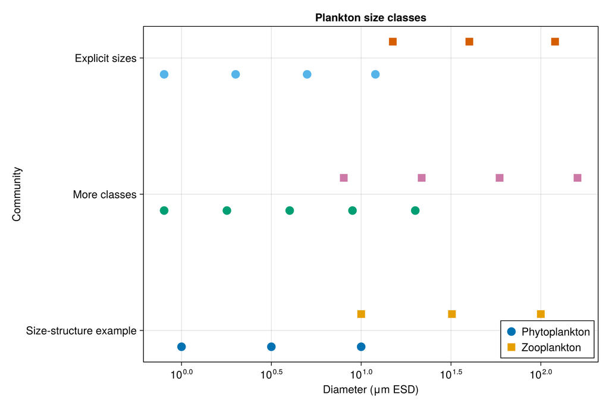

```julia
fig_sizes = Figure(; size = (900, 600), fontsize = 16)
ax_sizes = Axis(fig_sizes[1, 1]; xlabel = "Diameter (μm ESD)", ylabel = "Community", title = "Plankton size classes", xscale = log10)

for (row, (name, community)) in enumerate(pairs(communities))
    P_sizes = size_vector(community.phyto_size_structure)
    Z_sizes = size_vector(community.zoo_size_structure)

    scatter!(ax_sizes, P_sizes, fill(row - 0.12, length(P_sizes)); marker = :circle, markersize = 18, label = row == 1 ? "Phytoplankton" : nothing)
    scatter!(ax_sizes, Z_sizes, fill(row + 0.12, length(Z_sizes)); marker = :rect, markersize = 18, label = row == 1 ? "Zooplankton" : nothing)
end

ax_sizes.yticks = (1:length(communities), [community.title for community in communities])
axislegend(ax_sizes; position = :rb)
save(joinpath("figures", "04_size_classes.png"), fig_sizes)
fig_sizes
```

## Run zero-dimensional ecosystem simulations

We next run each community in a well-mixed box model. Initial plankton biomass is distributed evenly within phytoplankton and zooplankton so that changing `n` does not automatically change total initial biomass.

```julia
function initial_conditions(bgc; total_P = 0.12, total_Z = 0.03)
    tracers = tracer_names(bgc)
    P_tracers = filter(tracer -> startswith(String(tracer), "P"), tracers)
    Z_tracers = filter(tracer -> startswith(String(tracer), "Z"), tracers)

    values = Dict{Symbol, Float64}(:N => 8.0, :D => 0.01)

    for tracer in P_tracers
        values[tracer] = total_P / length(P_tracers)
    end

    for tracer in Z_tracers
        values[tracer] = total_Z / length(Z_tracers)
    end

    return (; (tracer => values[tracer] for tracer in tracers)...)
end

function run_box_model(bgc; filename)
    light_attenuation = FunctionFieldPAR(; grid = BoxModelGrid())
    bgc_model = Biogeochemistry(bgc; light_attenuation)
    full_model = BoxModel(; biogeochemistry = bgc_model)

    set!(full_model; initial_conditions(bgc)...)

    simulation = Simulation(full_model; Δt = 240minutes, stop_time = 1095days)

    simulation.output_writers[:fields] = JLD2Writer(
        full_model,
        full_model.fields;
        filename,
        schedule = TimeInterval(1day),
        overwrite_existing = true,
    )

    run!(simulation)
    return (; filename, tracer_syms = tracer_names(bgc))
end

outputs = (; (
    name => run_box_model(bgc; filename = joinpath("outputs", "04_$(name).jld2"))
    for (name, bgc) in pairs(bgcs)
)...)
```

```
[ Info: Initializing simulation...
[ Info:     ... simulation initialization complete (2.824 ms)
[ Info: Executing initial time step...
[ Info:     ... initial time step complete (212.778 μs).
[ Info: Simulation is stopping after running for 5.186 seconds.
[ Info: Simulation time 1095 days equals or exceeds stop time 1095 days.
[ Info: Initializing simulation...
[ Info:     ... simulation initialization complete (1.177 seconds)
[ Info: Executing initial time step...
[ Info:     ... initial time step complete (1.290 seconds).
[ Info: Simulation is stopping after running for 8.868 seconds.
[ Info: Simulation time 1095 days equals or exceeds stop time 1095 days.
[ Info: Initializing simulation...
[ Info:     ... simulation initialization complete (1.017 seconds)
[ Info: Executing initial time step...
[ Info:     ... initial time step complete (983.956 ms).
[ Info: Simulation is stopping after running for 7.735 seconds.
[ Info: Simulation time 1095 days equals or exceeds stop time 1095 days.
```

## Median and mean plankton size through time

The workshop diagnostics include plots of community size structure. Here we calculate two related summaries from each simulation:

- the biomass-weighted mean size, which responds smoothly to biomass shifts;
- the biomass-weighted median size, which is the size at which half the living plankton biomass is smaller and half is larger.

```julia
function weighted_median_size(sizes, biomass)
    valid = isfinite.(sizes) .& isfinite.(biomass) .& (biomass .> 0)
    any(valid) || return NaN

    valid_sizes = sizes[valid]
    valid_biomass = biomass[valid]
    total = sum(valid_biomass)
    total <= 0 && return NaN

    order = sortperm(valid_sizes)
    sorted_sizes = valid_sizes[order]
    sorted_biomass = valid_biomass[order]
    cumulative = cumsum(sorted_biomass) ./ total

    idx = findfirst(c -> c >= 0.5, cumulative)
    isnothing(idx) && return sorted_sizes[end]
    return sorted_sizes[idx]
end

function weighted_mean_size(sizes, biomass)
    valid = isfinite.(sizes) .& isfinite.(biomass) .& (biomass .> 0)
    any(valid) || return NaN

    valid_sizes = sizes[valid]
    valid_biomass = biomass[valid]
    total = sum(valid_biomass)
    total <= 0 && return NaN

    return sum(valid_sizes .* valid_biomass) / total
end

function read_size_summary(output, community)
    filename = output.filename
    tracer_syms = output.tracer_syms
    times = FieldTimeSeries(filename, string(first(tracer_syms))).times ./ day

    P_sizes = size_vector(community.phyto_size_structure)
    Z_sizes = size_vector(community.zoo_size_structure)
    sizes = [P_sizes..., Z_sizes...]
    plankton = [filter(tracer -> startswith(String(tracer), "P"), tracer_syms)...,
                filter(tracer -> startswith(String(tracer), "Z"), tracer_syms)...]

    biomass = reduce(hcat, [collect(FieldTimeSeries(filename, string(tracer))[1, 1, 1, :]) for tracer in plankton])
    total_biomass = vec(sum(biomass; dims = 2))

    mean_size = [weighted_mean_size(sizes, biomass[i, :]) for i in axes(biomass, 1)]
    median_size = [weighted_median_size(sizes, biomass[i, :]) for i in axes(biomass, 1)]

    final_biomass = biomass[end, :]

    return (; times = collect(times), sizes, plankton, biomass, final_biomass, mean_size, median_size, total_biomass)
end

summaries = (; (name => read_size_summary(outputs[name], community) for (name, community) in pairs(communities))...)
```

## Plot size summaries

The top panel compares the final biomass across size classes. The lower panels show the community mean and median size over time.

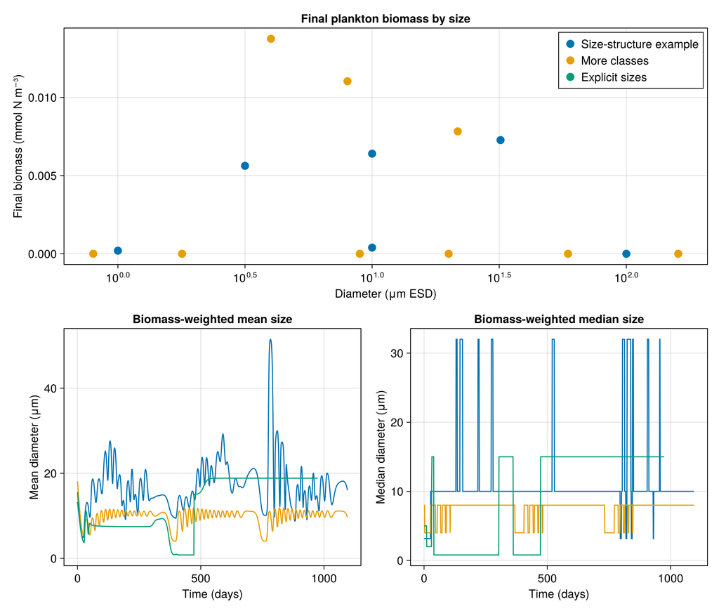

```julia
fig_summary = Figure(; size = (1000, 850), fontsize = 16)

ax_final = Axis(fig_summary[1, 1:2]; xlabel = "Diameter (μm ESD)", ylabel = "Final biomass (mmol N m⁻³)", title = "Final plankton biomass by size", xscale = log10)
ax_mean = Axis(fig_summary[2, 1]; xlabel = "Time (days)", ylabel = "Mean diameter (μm)", title = "Biomass-weighted mean size")
ax_median = Axis(fig_summary[2, 2]; xlabel = "Time (days)", ylabel = "Median diameter (μm)", title = "Biomass-weighted median size")

for (name, summary) in pairs(summaries)
    label = communities[name].title

    scatter!(ax_final, summary.sizes, summary.final_biomass; markersize = 16, label)
    lines!(ax_mean, summary.times, summary.mean_size; label)
    lines!(ax_median, summary.times, summary.median_size; label)
end

axislegend(ax_final; position = :rt)
save(joinpath("figures", "04_size_dynamics.png"), fig_summary)
fig_summary
```

## Compare linear and logarithmic splitting

Linear splitting places equal distance between diameters. Logarithmic splitting places equal distance between the logarithms of diameters. The latter is often more useful when size spans orders of magnitude.

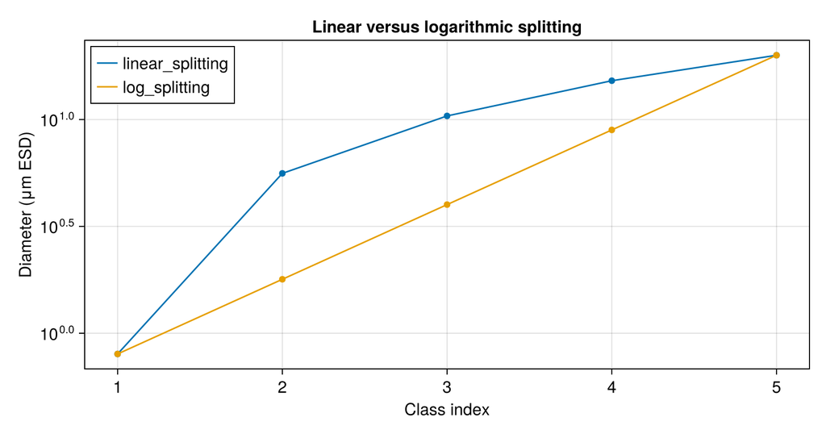

```julia
linear_phyto = (n = 5, min_esd = 0.8, max_esd = 20.0, splitting = :linear_splitting)
log_phyto = (n = 5, min_esd = 0.8, max_esd = 20.0, splitting = :log_splitting)

fig_splitting = Figure(; size = (800, 420), fontsize = 16)
ax_split = Axis(fig_splitting[1, 1]; xlabel = "Class index", ylabel = "Diameter (μm ESD)", title = "Linear versus logarithmic splitting", yscale = log10)

lines!(ax_split, 1:linear_phyto.n, size_vector(linear_phyto); label = "linear_splitting")
scatter!(ax_split, 1:linear_phyto.n, size_vector(linear_phyto))

lines!(ax_split, 1:log_phyto.n, size_vector(log_phyto); label = "log_splitting")
scatter!(ax_split, 1:log_phyto.n, size_vector(log_phyto))

axislegend(ax_split; position = :lt)
save(joinpath("figures", "04_linear_vs_log_splitting.png"), fig_splitting)
fig_splitting
```

## Exercises

1. Change `n` for phytoplankton from 3 to 6 in the `size_structure` community. How do the tracer names and initial conditions change?
2. Change `min_esd` and `max_esd` for zooplankton. How does the final biomass distribution move across the size axis?
3. Compare `:linear_splitting` and `:log_splitting` over the same size range. Which one gives more resolution to small plankton?
4. Replace one generated size structure with an explicit vector. When would explicit sizes be preferable to a generated range?